# SVD++ and History-Derived Factors

From matrix factorization to representations built from interaction history

Ben Dai

CUHK · Department of Statistics and Data Science

## Start with the MF prediction rule

$$\widehat r_{ui}=p_u^\top q_i$$

USER**$p_u\in\mathbb R^K$**

A free vector learned for user $u$.

ITEM**$q_i\in\mathbb R^K$**

A free vector learned for item $i$.

MF fits each user vector using that user’s observed ratings. What if a user has very few?

## Histories are uneven

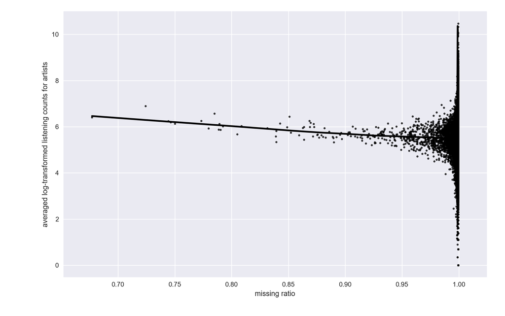

Example from the original LastFM slides: interaction counts are far from uniform.

A short history gives little direct evidence for a free $p_u$; a long history offers much more.

## Define the observed history carefully

$$I_u=\{j:(u,j)\in\Omega_{\mathrm{train}}\},\qquad \tau_u=|I_u|^{-1/2}$$

$I_u$**items in user $u$’s history**

Only training interactions enter this set.

$\tau_u$**history-size normalization**

Scales the sum so a long history does not automatically dominate.

When we validate or test, we construct $I_u$ from the training fold—never from held-out ratings.

## Build a user vector from the items

$$h_u=\tau_u\sum_{j\in I_u}w_j,\qquad w_j\in\mathbb R^K$$

rated/visited items  
$I_u$

*→*

learned vectors  
$w_j$

*→*

sum and scale  
$h_u$

The presence of an item contributes $w_j$. Its rating value is still used in the fitting loss.

## A small history example

Suppose user $u$ has training interactions with items A, B, and C.

$$h_u=\frac{w_{\mathrm A}+w_{\mathrm B}+w_{\mathrm C}}{\sqrt{3}}$$

SHARED SIGNAL**same item, same $w_j$**

All users who interacted with B share B’s learned contribution.

PERSONALIZED MIX**different item sets**

Different histories add different combinations of vectors.

## History-derived MF: the prediction

$$\widehat r_{ui}=q_i^\top h_u,\qquad h_u=|I_u|^{-1/2}\sum_{j\in I_u}w_j$$

REPLACE**free $p_u$ → history-derived $h_u$**

The user representation is now built from learned item-history vectors.

KEEP**item factor $q_i$**

The prediction is still a dot product.

The original slides call this L-SVD / N-SVD; here we use “history-derived MF” to emphasize its mechanism.

## History-derived MF: four questions

1 · MODEL**$q_i^\top h_u$**

$h_u$ is the normalized sum of $w_j$ over $I_u$.

2 · HYPERPARAMETERS**$K$ and $\lambda$**

Choose vector dimension and regularization strength.

3 · FITTING CRITERION**squared rating error + penalty**

Use only observed training pairs.

4 · LEARNED PARAMETERS**$Q$ and $W$**

Fit item factors $q_i$ and history contributions $w_j$.

## The fitting criterion

$$\min_{Q,W}\ \sum_{(u,i)\in\Omega_{\mathrm{train}}}(r_{ui}-q_i^\top h_u)^2+\lambda\sum_j\bigl(\|q_j\|_2^2+\|w_j\|_2^2\bigr)$$

$$h_u=|I_u|^{-1/2}\sum_{j\in I_u}w_j$$

Changing $w_j$ affects every training user whose history contains item $j$.

## One block is familiar ridge regression

Fix all history vectors $W$. Then every $h_u$ is a known input vector.

$$\widehat q_i=\arg\min_q\ \sum_{u:(u,i)\in\Omega_{\mathrm{train}}}(r_{ui}-q^\top h_u)^2+\lambda\|q\|_2^2$$

known $h_u$

*→*

ridge fit for each item $i$

*→*

updated $q_i$

This is the same fixed-one-side idea used in MF’s alternating least squares.

## The history-vector block is coupled

Now fix $Q$. A single $w_j$ appears in many users’ sums.

$$j\in I_u\quad\Longrightarrow\quad w_j\text{ contributes to }h_u\text{ and all predictions for }u$$

WHY HARDER?**shared contribution**

Updating $w_j$ changes several users at once.

PRACTICAL ROUTES**coordinate or gradient updates**

Hold other vectors fixed, or optimize all vectors with gradients.

## The limit: identical histories

$$I_a=I_b\quad\Longrightarrow\quad h_a=h_b$$

USER A**A, B, C**

Liked A strongly; disliked C.

USER B**A, B, C**

Disliked A; liked C strongly.

The two users receive the same history-derived vector even when their rating values differ.

## SVD++ adds a user-specific vector

$$\widehat r_{ui}=q_i^\top\left(p_u+h_u\right),\qquad h_u=|I_u|^{-1/2}\sum_{j\in I_u}w_j$$

$p_u$**individual evidence**

Learned from user $u$’s rating values.

$h_u$**shared history evidence**

Built from vectors of items in the training history.

Users A and B can now differ through $p_a$ and $p_b$, even when $I_a=I_b$.

## SVD++: four questions

1 · MODEL**$q_i^\top(p_u+h_u)$**

A free user factor plus a history-derived factor.

2 · HYPERPARAMETERS**$K$ and $\lambda$**

Choose factor dimension and penalty strength.

3 · FITTING CRITERION**regularized squared error**

Compare predictions with training ratings.

4 · LEARNED PARAMETERS**$P$, $Q$, and $W$**

User factors, item factors, and history contributions.

## SVD++ fitting criterion

$$\min_{P,Q,W}\ \sum_{(u,i)\in\Omega_{\mathrm{train}}}\left[r_{ui}-q_i^\top(p_u+h_u)\right]^2+\lambda\left(\|P\|_F^2+\|Q\|_F^2+\|W\|_F^2\right)$$

$$h_u=|I_u|^{-1/2}\sum_{j\in I_u}w_j$$

This writes the objective as a sum; using mean error would rescale the numerical value of $\lambda$.

## How to fit it

fix $Q,W$  
update $P$

*→*

fix $P,W$  
update $Q$

*→*

fix $P,Q$  
update $W$

*↺*

ALTERNATING VIEW**ridge-like blocks**

The $P$ and $Q$ blocks are ridge problems when the other vectors are fixed.

GRADIENT VIEW**one differentiable loss**

SGD or Adam can update $P$, $Q$, and $W$ together.

The learning algorithm is separate from the model formula: the same rule can be fitted in different ways.

## Choose settings without leaking history

training pairs  
fit $P,Q,W$

*→*

validation pairs  
select $K,\lambda$

*→*

test pairs  
report once

For each split, construct $I_u$ from its training interactions. A validation/test pair must not reveal itself through the history feature used to predict it.

A completely new user still has neither a fitted $p_u$ nor a nonempty history; SVD++ alone does not solve that cold start.

## Nearby extensions from the original deck

NMF**constrain factors**

Keep the MF dot product but require $P,Q\geq0$.

GROUP MF**add group vectors**

Use known user/item groups to share structure.

SMOOTH MF**borrow from neighbors**

Weight nearby user/item observations during fitting.

Each variant changes a different module: feasible parameters, prediction rule, or fitting criterion.

## Reuse the four questions

|  | MF | History-derived MF | SVD++ |
| --- | --- | --- | --- |
| Model | $q_i^\top p_u$ | $q_i^\top h_u$ | $q_i^\top(p_u+h_u)$ |
| Learned | $P,Q$ | $Q,W$ | $P,Q,W$ |
| Hyperparameters | $K,\lambda$ | $K,\lambda$ | $K,\lambda$ |
| Criterion | regularized error on observed training ratings |  |  |

Adding the history path changes how users are represented; evaluation still follows the same train/validation/test discipline.